# Cigarros y regresión

José Miguel Hernández Cabrera

## Introducción

*Nota: algunos conceptos muestran sus definiciones al posicionar el cursor sobre el texto. Tienes que leer activamente para poder descubrirlas.*

La

[interactive chart not shown]

cada año analiza las distintas marcas de tabaco de acuerdo a su contenido en alquitrán, nicotina y monóxido de carbono. *The United States Surgeon General* considera cada una de estas sustancias peligrosas para la salud de los fumadores. Estudios pasados ponen de manifiesto que incrementos en el contenido de alquitrán y nicotina de los cigarros vienen acompañados por incrementos en el monóxido de carbono emitido al fumar un cigarro (Lauren 1994). Los datos que se presentan [aquí](https://mste.illinois.edu/malcz/DATA/SOCIALSCIENCE/Cigarettes.html) fueron tomados de Mendenhall and Sincich (1992).

Antes de continuar, me aseguré de tener los datos en una carpeta llamada `data` contenida dentro de mi carpeta `.Rproj` para tener un directorio ordenado. Recomiendo usar [RStudio Projects](https://support.rstudio.com/hc/en-us/articles/200526207-Using-Projects) para evitar tener que utilizar `setwd()`en cada ocasión y no tener que preocuparse por establecer un entorno de trabajo cada vez que uno inicie sesión.

Primero, cargamos la biblioteca `readxl` para importar a R el archivo que se llamará `ciga`:

```r
library(readxl)

ciga = read_excel(path = "data/ciga.xls")
```

Una vez importados, hay que ver la e**str**uctura con la función `str()`.

```r
str(ciga)
```

```
## Classes 'tbl_df', 'tbl' and 'data.frame':    25 obs. of  6 variables:
##  $ Marca: chr  "Alpine" "Benson&Hedges" "BullDurham" "CamelLights" ...
##  $ Alq  : num  14.1 16 29.8 8 4.1 15 8.8 12.4 16.6 14.9 ...
##  $ Nic  : num  0.86 1.06 2.03 0.67 0.4 1.04 0.76 0.95 1.12 1.02 ...
##  $ Pes  : num  0.985 1.094 1.165 0.928 0.946 ...
##  $ Light: num  0 0 0 1 0 0 1 0 0 0 ...
##  $ CO   : num  13.6 16.6 23.5 10.2 5.4 15 9 12.3 16.3 15.4 ...
```

De entre varias cosas, podemos ver que los datos se componen de 25

[interactive chart not shown]

y 6

[interactive chart not shown]

. De las variables, solo `Marca` es una variable nominal, todas las demás son cuantitativas.

Una forma más estadística de ver los datos es con la función `summary()`, la cual mostrará estadísticos descriptivos básicos. Esta función también será muy útil más adelante para ver los resultados de los modelos estadísticos que utilizaremos más adelante. Por ahora veamos cómo se comportan las variables de los cigarrillos.

```r
summary(ciga)
```

```
##     Marca                Alq             Nic              Pes
##  Length:25          Min.   : 1.00   Min.   :0.1300   Min.   :0.7851
##  Class :character   1st Qu.: 8.60   1st Qu.:0.6900   1st Qu.:0.9225
##  Mode  :character   Median :12.80   Median :0.9000   Median :0.9573
##                     Mean   :12.22   Mean   :0.8764   Mean   :0.9703
##                     3rd Qu.:15.10   3rd Qu.:1.0200   3rd Qu.:1.0070
##                     Max.   :29.80   Max.   :2.0300   Max.   :1.1650
##      Light            CO
##  Min.   :0.00   Min.   : 1.50
##  1st Qu.:0.00   1st Qu.:10.00
##  Median :0.00   Median :13.00
##  Mean   :0.28   Mean   :12.53
##  3rd Qu.:1.00   3rd Qu.:15.40
##  Max.   :1.00   Max.   :23.50
```

Aquí hay algo raro. En la función `str()` vimos que la variable `Light` se está integrada de `0` y `1`. Al usar `summary()`, naturalmente la máquina nos da sus descriptivos, pero resulta que esta variable es una

[interactive chart not shown]

que servirá para identificar si el cigarrillo es Light o no. Entonces no tiene sentido que Light tenga medidas de tendencia central. Como queremos que R detecte que es una variable especial, existen dos formas de hacerlo: convirtiendo la variable en [`logical`](https://es.r4ds.hadley.nz/transform.html) o en [`factor`](https://es.r4ds.hadley.nz/factores.html).

Para este ejercicio, convertiré la variable hacia la clase `factor`. Existen tres principales formas de hacerlo: con R `base`, con el amigable paquete `dplyr` de [`tidyverse`](https://www.tidyverse.org) y con el rapidísimo [`data.table`](https://github.com/Rdatatable/data.table). Cada uno tiene sus ventajas y desventajas. Mi favorito es `data.table`, pero por mucho tiempo utilicé `tidyverse` para hacerme la vida más fácil en R. Sin embargo, usaré como ejemplo solamente `base` porque no necesitamos instalar nada más.

Con base R, la forma de seleccionar las columnas es mediante la sintaxis `data.frame$columna` donde `$` es una forma de seleccionar la variable que nos interesa.

Actualmente la variable es de clase `numeric`. Esto lo comprobamos con la función `class()`:

```r
class(ciga$Light)
```

```
## [1] "numeric"
```

Para convertirla a `factor` utilizamos la función, adivina…, `factor()`:

```r
ciga$Light = factor(ciga$Light, levels = c(0, 1), labels = c("No", "Sí"))
```

Las funciones son instrucciones que se les da a la computadora (mediante R) para que ella las ejecute. Como podrás ver en los códigos anteriores, todas las funciones utilizan paréntesis `()` después de una palabra. Cada función se compone de *argumentos*, los cuales son parámetros o instrucciones específicas con las que la computadora trabajará. En el caso de nuestra variable

[interactive chart not shown]

, escribimos `levels` para determinar los *niveles* con los que el factor categorizará el `0` y el `1` (es una característica propia de R). El argumento `labels` se usa para etiquetar el `0` en `No` y el `1` en `Sí`. Aunque pudimos escribir simplemente `ciga$Light = factor(ciga$Light)`, la computadora habría tenido que adivinar cuáles son las categorías, sin que pusiera las etiquetas. Por eso siempre es mejor dar las instrucciones explícitamente.

Ahora veamos cómo reporta R a nuestra variable transformada:

```r
summary(ciga)
```

```
##     Marca                Alq             Nic              Pes
##  Length:25          Min.   : 1.00   Min.   :0.1300   Min.   :0.7851
##  Class :character   1st Qu.: 8.60   1st Qu.:0.6900   1st Qu.:0.9225
##  Mode  :character   Median :12.80   Median :0.9000   Median :0.9573
##                     Mean   :12.22   Mean   :0.8764   Mean   :0.9703
##                     3rd Qu.:15.10   3rd Qu.:1.0200   3rd Qu.:1.0070
##                     Max.   :29.80   Max.   :2.0300   Max.   :1.1650
##  Light         CO
##  No:18   Min.   : 1.50
##  Sí: 7   1st Qu.:10.00
##          Median :13.00
##          Mean   :12.53
##          3rd Qu.:15.40
##          Max.   :23.50
```

Podemos ver que ahora tenemos una tabla de frecuencias en lugar de medidas de tendencia central. También podemos comprobarlo vía la función `class()`.

```r
class(ciga$Light)
```

```
## [1] "factor"
```

## Regresión simple

Al principio de cualquier análisis, siempre comenzamos por hacer cada una de las regresiones simples de las variables por separado: Alquitrán `Alq`, Nicotina `Nic` y Peso `Pes`. Como la variable `Light` es nominal de momento no la incluiremos. El modelo es de la forma:

$$Y=\beta_0+\beta_1X_1$$

### Regresión para el alquitrán

Queremos saber qué tanto está relacionado el alquitrán sobre el

[interactive chart not shown]

Para ello usaremos el modelo $CO = \beta_0 + \beta_1Alq$, lo estimamos con la función `lm()` y lo interpretamos con `summary()`.

La función `lm()` corresponde a *linear model* y tiene dos argumentos: `formula`, cuya sintaxis es `variable_de_respuesta ~ variable_explicativa`, y `data`, en donde va la `data.frame` que corresponda.

Hay dos formas de escribir los argumentos: explícita o implícitamente. La forma explícita consiste en escribir el nombre del argumento y luego el contenido. La implícita es solamente poner el contenido del argumento dentro del orden en que aparece en la función. Para saber el orden, escribe `?` seguido del nombre de la función sin los paréntesis y aparecerá la hoja de ayuda. Intenta hacerlo con `?lm`. Para ilustrar esto, veamos cómo invocar argumentos de `lm()` en dos formas:

```r
# Forma explícita
lm(formula = CO ~ Alq, data = ciga)

# Forma implícita
lm(CO ~ Alq, ciga)
```

¿Siempre debemos escribir explícitamente las instrucciones? No necesariamente. En realidad depende mucho del público al que va dirigido y qué tan legible conviene ser. No siempre vale la pena explicar todo.

Por último, al modelo le llamaremos `modelo_a`, aunque podría ser `alq_lm`, o el nombre que sea. De hecho, nombrar los objetos [apropiadamente](https://es.r4ds.hadley.nz/flujo-de-trabajo-conocimientos-b%C3%A1sicos.html#) es una de las buenas prácticas para trabajar con datos. por lo pronto, el modelo queda de la siguiente forma:

```r
modelo_a = lm(CO ~ Alq, ciga)

summary(modelo_a)
```

```
##
## Call:
## lm(formula = CO ~ Alq, data = ciga)
##
## Residuals:
##     Min      1Q  Median      3Q     Max
## -3.1124 -0.7167 -0.3754  1.0091  2.5450
##
## Coefficients:
##             Estimate Std. Error t value Pr(>|t|)
## (Intercept)  2.74328    0.67521   4.063 0.000481 ***
## Alq          0.80098    0.05032  15.918 6.55e-14 ***
## ---
## Signif. codes:  0 '***' 0.001 '**' 0.01 '*' 0.05 '.' 0.1 ' ' 1
##
## Residual standard error: 1.397 on 23 degrees of freedom
## Multiple R-squared:  0.9168, Adjusted R-squared:  0.9132
## F-statistic: 253.4 on 1 and 23 DF,  p-value: 6.552e-14
```

Diseccionemos el montón de cosas que aparecen aquí. En la primera fila se encuentra `(Intercept)`, el cual corresponde a $\beta_0$ o la

[interactive chart not shown]

por sí no se puede interpretar. Luego, `Alq` es $\beta_1Alq$, el cual indica el

[interactive chart not shown]

de la ecuación. En las columnas están `Estimate` que son los valores estimados, `Std. Error` que es el error estándar, `t value` el valor estadístico de t y `Pr(>|t|)` el

[interactive chart not shown]

Así, la ecuación de regresión es $CO = 2.7432776 + 0.800976 * Alq$. El

[interactive chart not shown]

es $R^2 = 0.9167782$, por lo que el poder explicativo es alto debido a que el $91.68\%$ de la variabilidad del

[interactive chart not shown]

está explicado por el modelo de regresión.

Como las cosas se ven mejor visualmente, podemos dibujar un diagrama de dispersión con su recta ajustada. Para ello usaré el paquete [`ggplot2`](https://ggplot2.tidyverse.org/). Esta es la biblioteca más utilizada de R para hacer gráficos. `gg` corresponde a gramática de gráficos, la cual tiene unos fundamentos teóricos sobre visualización de datos [bastante interesante](https://es.r4ds.hadley.nz/visualizaci%C3%B3n-de-datos.html). Asegúrate de tener instalado `ggplot2` o `tidyverse` antes de cargarlo.

```r
library(ggplot2)
```

La sintaxis de ggplot es laboriosa pero fácil de captar: primero usamos la función `ggplot()` para crear el cuadro de dibujo. Dentro de esta función

[interactive chart not shown]

irá primero `data` y luego una subfunción llamada `aes()`. Esta subfunción corresponde a **aes**

[interactive chart not shown]

y determinan los ejes `x` y `y`, los colores `color`, el tamaño `size` y muchos otros argumentos.

Seguido de la función `ggplot()` se usan capas que se establecerán mediante el símbolo `+`. Luego, le siguen las diferentes [opciones de dibujo](https://ggplot2.tidyverse.org/reference/index.html), las cuales pueden ser tan simples o tan complejas como se requieran.

En la primera capa usaremos `geom_point()` para dibujar los puntos sobre la gráfica, sin argumentos. Esto es así porque `+` nos permite

[interactive chart not shown]

`data` y `aes()` a las funciones siguientes.

Finalmente, para crear la línea de ajuste en la siguiente capa usamos `geom_abline()`, la cual tiene dos argumentos: `intercept` y `slope`. ¿Te suenan?. La forma fácil de escribirlos es simplemente copiar y pegar de la consola los valores que correspondan. La forma precisa (y recomendada) es seleccionar los objetos mediante la sintaxis `objeto$variable[índice_fila, índice_columna]`, de tal manera que para seleccionar el punto de intercepción escribimos `modelo_a$coefficients[1]` y la pendiente `modelo_a$coefficients[2]`. Guardarmos la gráfica en el objeto `graf_a` y luego la imprimimos escribiendo el objeto en la siguiente línea.

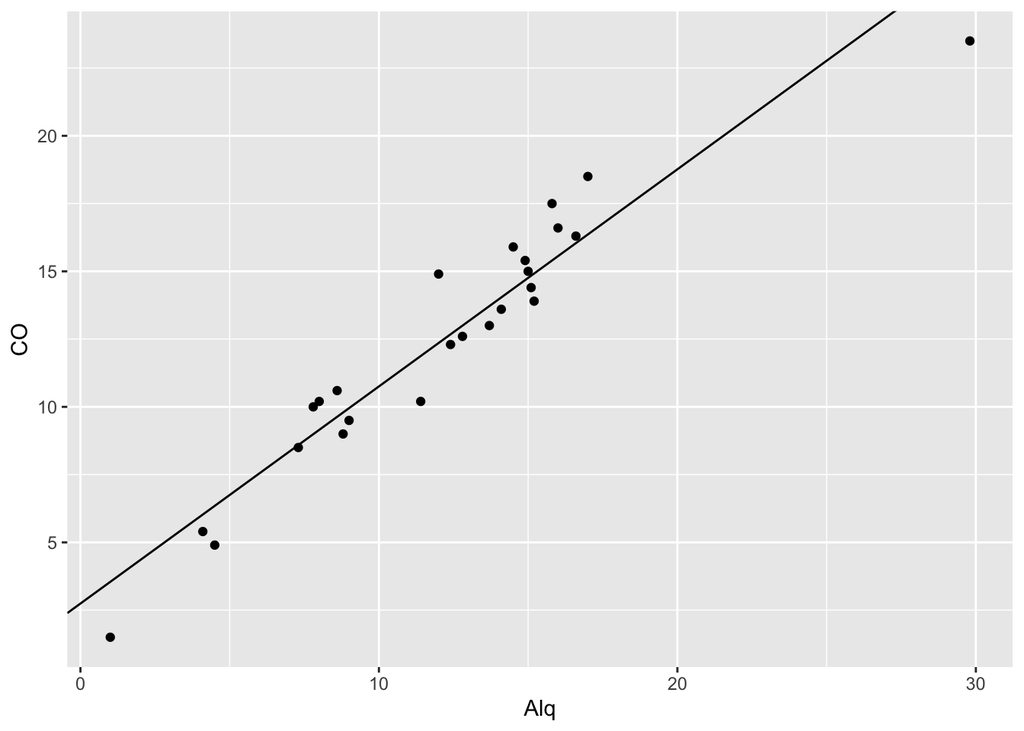

```r
graf_a = ggplot(data = ciga, aes(x = Alq, y = CO)) +
  # Dibuja los puntos
  geom_point() +
  # Dibuja la recta ajustada. Usamos el objeto "modelo_a" para precisión
  geom_abline(intercept = modelo_a$coefficients[1], slope = modelo_a$coefficients[2])

graf_a
```

La recta parece ajustarse bien a los datos. Solamentet el punto de la derecha parece estar fuera del patrón de los demás. Podría ser que se trate de un

[interactive chart not shown]

Por el momento, consultando el $p-valor$ mediante `summary(modelo_a)[["coefficients"]][2,4]`, podemos ver que el modelo explica una parte significativa de la variabilidad de la respuesta y el coeficiente de regresión es significativamente distinto de cero $p = 6.5522448\times 10^{-14}$. Dado que tenemos solamente una variable, ambos contrastes tienen el mismo $p-valor$.

Probamos algunos diagnósticos para comprobar si el modelo se encuencuentra en buenas condiciones. R `base` tiene una forma insuperable de mostrar el diagnóstico de un modelo; en pocas líneas puede decirnos un montón de información. La única desventaja es que los resultados los da en inglés y las gráficas son difíciles de manipular. Existen [otras](https://drsimonj.svbtle.com/visualising-residuals) formas de hacer los diagnósticos con `ggplot`, pero es demasiado para lo que queremos.

Si ponemos `plot(modelo_a)` nos da cuatro diagnósticos:

[interactive chart not shown]

y

[interactive chart not shown]

.

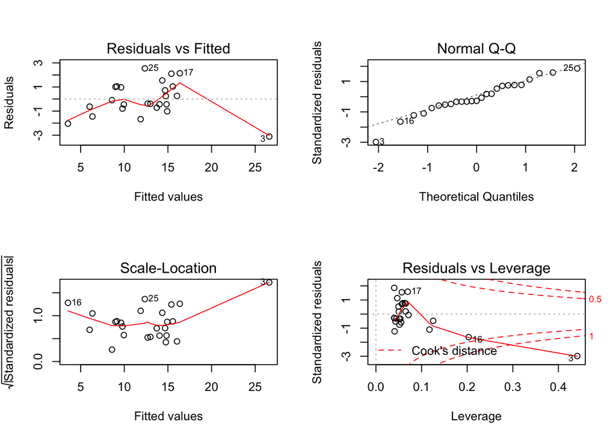

```r
# Especificamos que queremos los cuatro diagnósticos en una solo panel de 2x2.
par(mfrow = c(2, 2))

# Imprimimos los diagnósticos
plot(modelo_a)
```

Veamos qué significa cada uno.

#### Residuales vs valores ajustados

Esta gráfica muestra si los

[interactive chart not shown]

tienen patrones no-lineales. Puede que exista una relación no-lineal entre las variables explicativas y la variable de respuesta y esta gráfica nos ayuda a saber si el modelo no captura esa información. Si en la gráfica se muestran los puntos dispersos por todo el cuadro, es una buena señal de que no existen relaciones no-lineales.

En nuestro modelo, los puntos se ven sin un patrón específico, salvo por la observación `3`. Primera señal de que algo no anda bien.

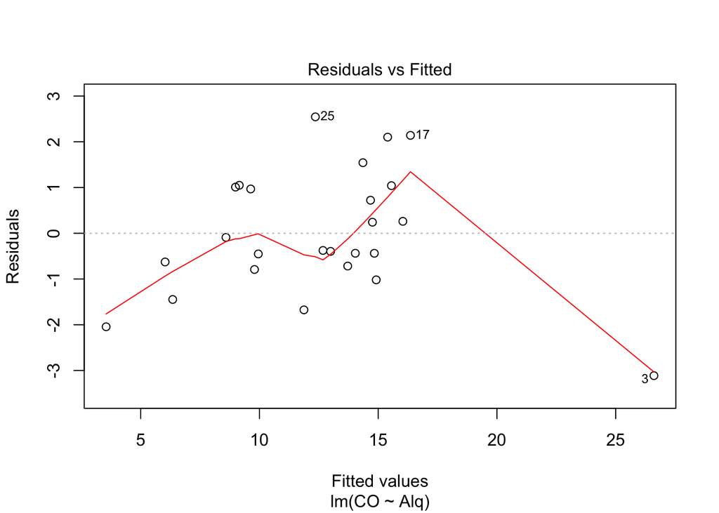

```r
plot(modelo_a, which = 1)
```

#### Quantiles teoréticos

El gráfico Q-Q muestra si los residuales distribuyen aproximadamente como una normal. Los residuales que siguen este patrón se ajustan bien a la línea punteada.

De nuevo, casi todos lo datos se ven bien con excepción de la observación `3`.

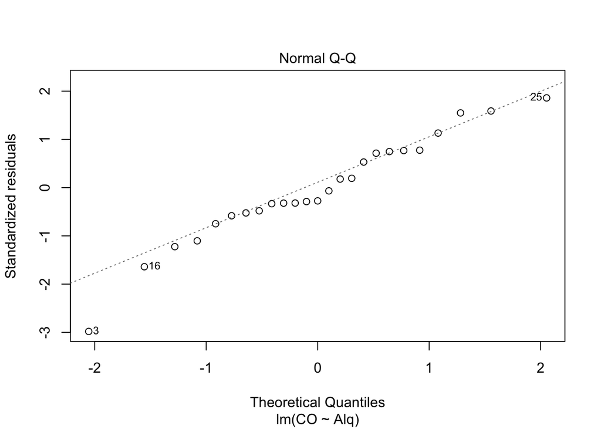

```r
plot(modelo_a, which = 2)
```

#### Escala-Ubicación

También llamada

[interactive chart not shown]

sirve para revisar si se cumple el supuesto de

[interactive chart not shown]

En otras palabras, muestra si los residuales se distribuyen equitativamente a lo largo de los rangos de los predictores. Eso se hace con con la $\sqrt{residuales estandarizados}$ contra los valores ajustados modelo. Lo que se espera de un buen modelo es que se vea una línea casi horizontal con puntos distribuidos aleatoriamente o sin algún patrón en particular. Cualquier otra cosa es mala señal.

En nuestro caso, de nuevo el `3` provoca que la línea roja se distorsione.

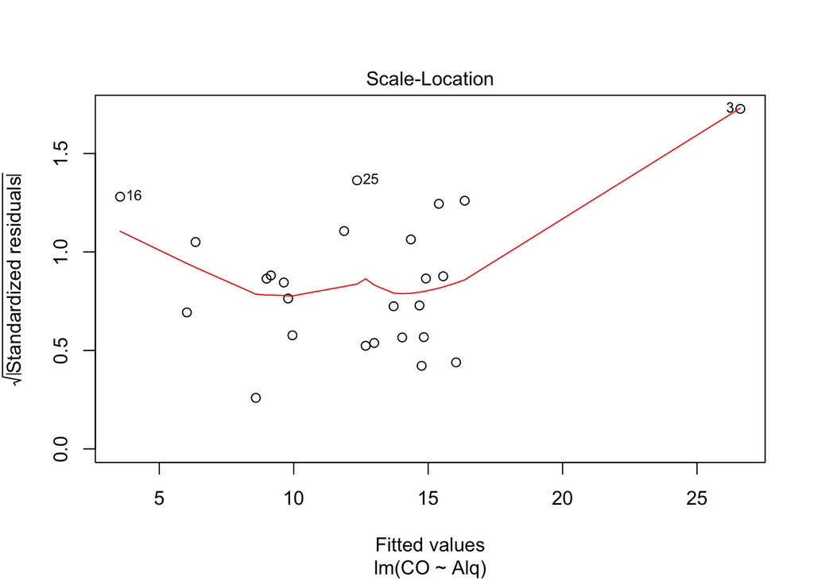

```r
plot(modelo_a, which = 3)
```

#### Residuales vs potencial

Finalmente, esta gráfica ayuda a identificar si existen casos que influyen en el modelo. No todos los valores atípicos potencialmente influyen en una regresión lineal, incluso si se llegaran a presentar como valores extremos. Esto implica que hay resultados que no necesariamente cambian en caso de excluir o incluirlos del análisis. No son influyentes si siguen el patrón general y no hacen mucho ruido.

Por otra parte, hay otros valores que podrían influir mucho en el modelo incluso si parece que están dentro del rango razonable de valores. Pueden ser tan extremos que incluso pueden alterar el resultado del análisis al excluirlos. Es decir, puede que no sigan el patrón general.

A diferencia de las otras gráficas, el patrón en la que se dispersan los puntos no es importante. En cambio, usaremos la

[interactive chart not shown]

para detectar a las observaciones influyentes. Entre más alto el puntaje, más influyente es. En el gráfico se dibujan con líneas punteadas las distancas mayores a `0.5` y `1`. En general, se considera a un valor como atípico influyente si la distancia de Cook es mayor a `1`.

En nuestra gráfica vemos que el número `3` tiene una distancia mayor a `1` y, por lo tanto, deberíamos observar un cambio en los resultados del modelo al excluir este valor.

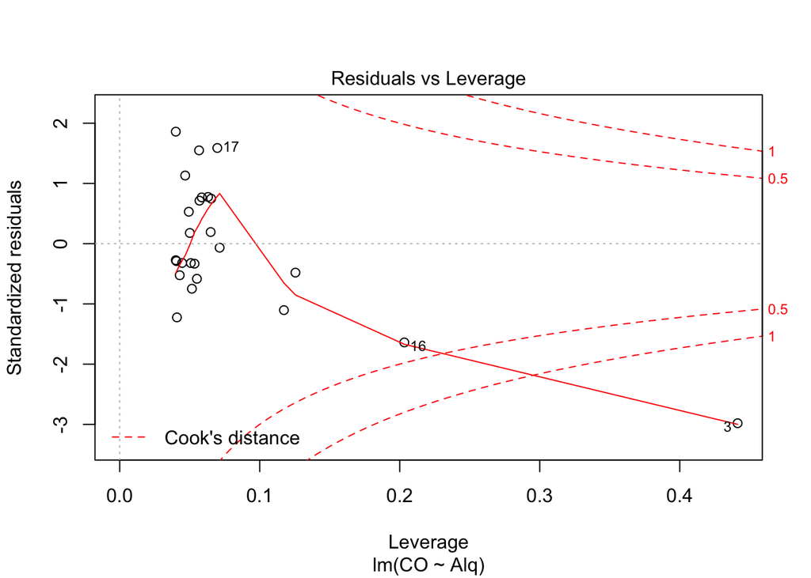

```r
plot(modelo_a, which = 5)
```

#### Reajustando modelo

¿Cuál es ese valor `3` que hace tanto ruido? Hay dos formas de averiguarlo. La más obvia y fácil es seleccionarlo desde `ciga` mediante la sintaxis `data.frame[índice_fila, índice_columna]`. Con R `base` es posible ver una observación con todas las columnas con la sintaxis `data.frame[índice_fila, ]`.

```r
ciga[3, ]
```

```
## # A tibble: 1 x 6
##   Marca        Alq   Nic   Pes Light    CO
##   <chr>      <dbl> <dbl> <dbl> <fct> <dbl>
## 1 BullDurham  29.8  2.03  1.16 No     23.5
```

Podemos ver que es la marca BullDurham. La otra forrma es agregar la función `geom_text` a nuestro `graf_a`. Para ello agregamos una capa con `+` y como argumentos usamos `aes(label = texto)` para poner la `Marca`, `vjust` para que el texto lo mande abajo del punto y `hjust` para que lo envíe a la izquierda.

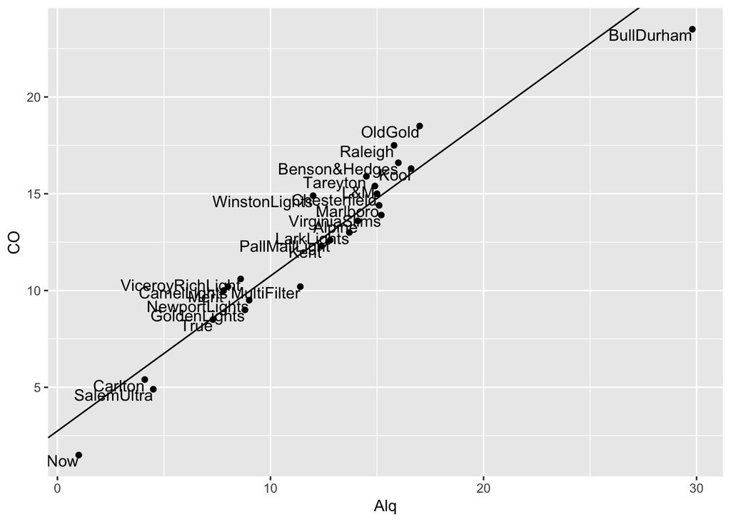

```r
graf_a +
  geom_text(aes(label = Marca), vjust = 1, hjust = 1)
```

De esta manera, ya comprobamos por dos vías distintas que la marca BullDurham causa mucho ruido. Crearemos una nueva `data.frame` sin esa observación indicando a R que no queremos la observación `3` con un signo de `-` en la sintaxis `data.frame[-índice_fila, ]`.

```r
ciga_2 = ciga[-3, ]
```

Ahora repitamos todo el proceso anterior con `ciga_2`

```r
modelo_a_sin_out = lm(CO ~ Alq, ciga_2)

summary(modelo_a_sin_out)
```

```
##
## Call:
## lm(formula = CO ~ Alq, data = ciga_2)
##
## Residuals:
##     Min      1Q  Median      3Q     Max
## -1.7935 -0.7299 -0.3004  1.0733  2.3496
##
## Coefficients:
##             Estimate Std. Error t value Pr(>|t|)
## (Intercept)  1.41285    0.64822    2.18   0.0403 *
## Alq          0.92813    0.05283   17.57 1.96e-14 ***
## ---
## Signif. codes:  0 '***' 0.001 '**' 0.01 '*' 0.05 '.' 0.1 ' ' 1
##
## Residual standard error: 1.119 on 22 degrees of freedom
## Multiple R-squared:  0.9335, Adjusted R-squared:  0.9304
## F-statistic: 308.6 on 1 and 22 DF,  p-value: 1.964e-14
```

La ecuación de regresión cambió a $CO = 1.4128544 + 0.9281259 * Alq$. Ahora el $93.34\%$ de la variabilidad es explicada por el modelo, dado que la

[interactive chart not shown]

es $R^2 = 0.9334619$.

El diagrama de dispersión ahora se ve de la forma siguiente:

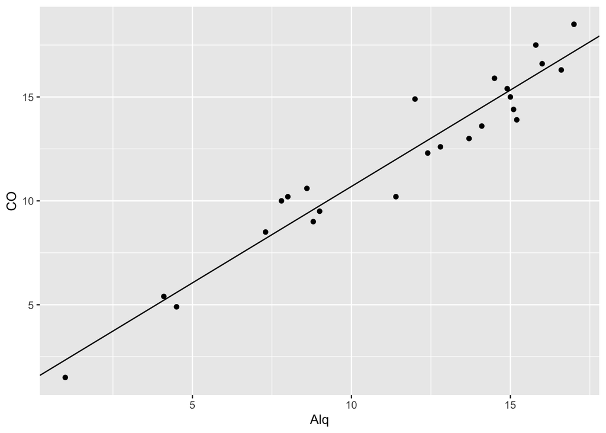

```r
ggplot(ciga_2, aes(Alq, CO)) +
  geom_point() +
  geom_abline(intercept = modelo_a_sin_out$coefficients[[1]], slope = modelo_a_sin_out$coefficients[[2]])
```

¡Se ve bien! Ahora veamos el diagnóstico de residuales.

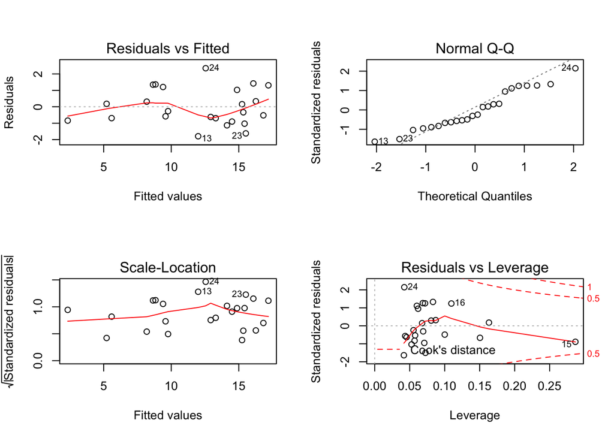

```r
par(mfrow = c(2, 2))
plot(modelo_a_sin_out)
```

En esta ocasión, cada gráfica se muestra como uno esperaría de un buen modelo. Incluso podemos que las líneas puntadas de la distancia de Cook casi no se ven porque todas las observaciones se comportan dentro del patrón general.

Ahora bien, muy bonitas las gráficas y bastante ilustrativa la manipulación de datos, pero ¿a dónde vamos con todo esto? ¿Qué significa que ahora tengamos un buen modelo? Todavía no podemos sacar una conclusión final porque falta analizar el resto de las variables con respecto al CO.

Por lo pronto, con nuestro modelo del alquitrán sin el dato atípico, podemos decir que con cada cambio en una unidad de alquitrán, el CO emitido al fumar aumenta en $0.92813$.

### Regresión para la Nicotina

Toca ajustar la regresión para la nicotina. Realizamos el mismo ejercicio que con el alquitrán.

```r
modelo_n = lm(CO ~ Nic, ciga)

summary(modelo_n)
```

```
##
## Call:
## lm(formula = CO ~ Nic, data = ciga)
##
## Residuals:
##     Min      1Q  Median      3Q     Max
## -3.3273 -1.2228  0.2304  1.2700  3.9357
##
## Coefficients:
##             Estimate Std. Error t value Pr(>|t|)
## (Intercept)   1.6647     0.9936   1.675    0.107
## Nic          12.3954     1.0542  11.759 3.31e-11 ***
## ---
## Signif. codes:  0 '***' 0.001 '**' 0.01 '*' 0.05 '.' 0.1 ' ' 1
##
## Residual standard error: 1.828 on 23 degrees of freedom
## Multiple R-squared:  0.8574, Adjusted R-squared:  0.8512
## F-statistic: 138.3 on 1 and 23 DF,  p-value: 3.312e-11
```

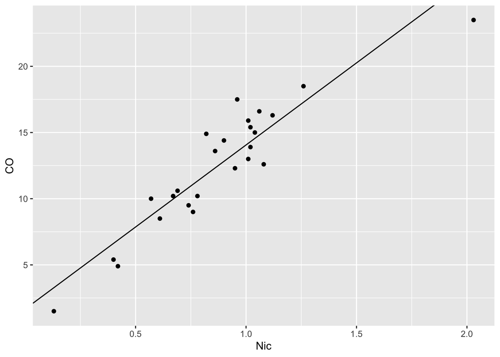

```r
graf_n = ggplot(ciga, aes(Nic, CO)) +
  geom_point() +
  geom_abline(intercept = modelo_n$coefficients[[1]], slope = modelo_n$coefficients[[2]])
graf_n
```

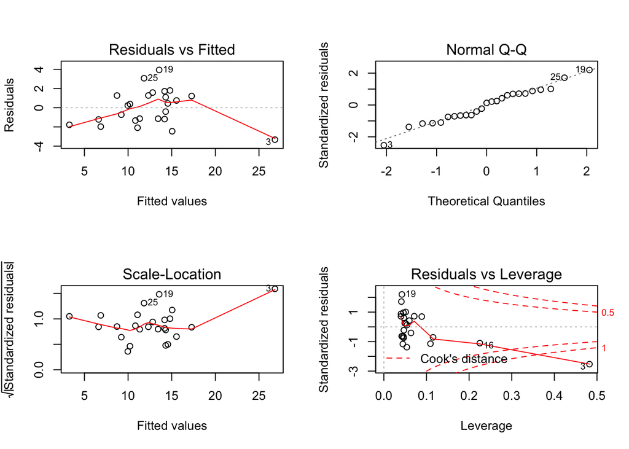

```r
par(mfrow = c(2, 2))
plot(modelo_n)
```

Vemos que otra vez el número `3` vuelve a hacer de las suyas. Veamos cómo se comporta nuestro modelo con nicotina sin la `Marca` BullDurham.

#### Nicotina sin atípico

```r
modelo_n_sin_out = lm(CO ~ Nic, ciga_2)

summary(modelo_n_sin_out)
```

```
##
## Call:
## lm(formula = CO ~ Nic, data = ciga_2)
##
## Residuals:
##     Min      1Q  Median      3Q     Max
## -3.2106 -1.1154 -0.1493  1.0656  3.4726
##
## Coefficients:
##             Estimate Std. Error t value Pr(>|t|)
## (Intercept)  -0.2382     1.0827   -0.22    0.828
## Nic          14.8600     1.2471   11.92 4.55e-11 ***
## ---
## Signif. codes:  0 '***' 0.001 '**' 0.01 '*' 0.05 '.' 0.1 ' ' 1
##
## Residual standard error: 1.588 on 22 degrees of freedom
## Multiple R-squared:  0.8658, Adjusted R-squared:  0.8597
## F-statistic:   142 on 1 and 22 DF,  p-value: 4.551e-11
```

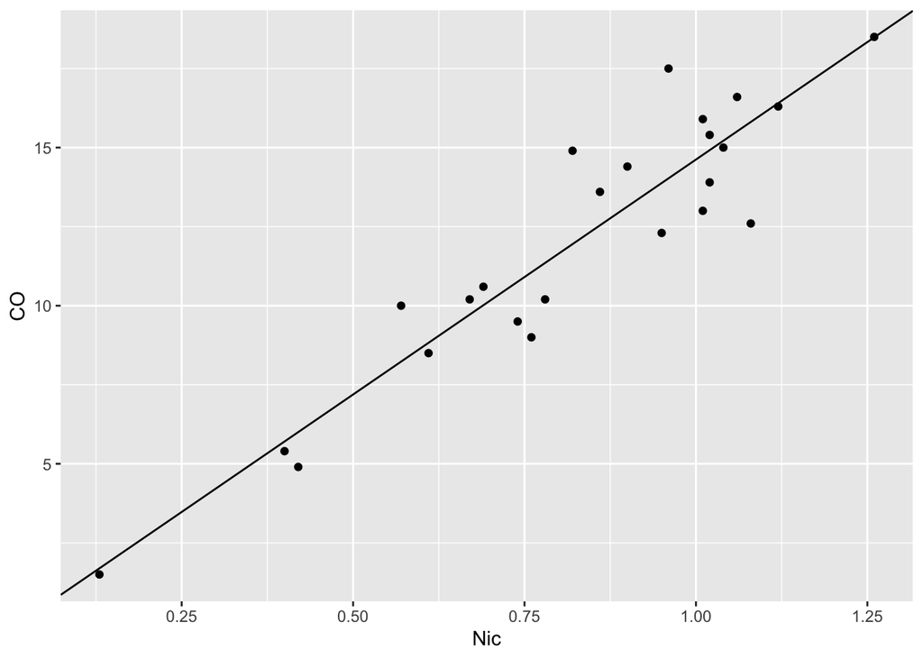

```r
ggplot(ciga_2, aes(Nic, CO)) +
  geom_point() +
  geom_abline(intercept = modelo_n_sin_out$coefficients[[1]], slope = modelo_n_sin_out$coefficients[[2]])
```

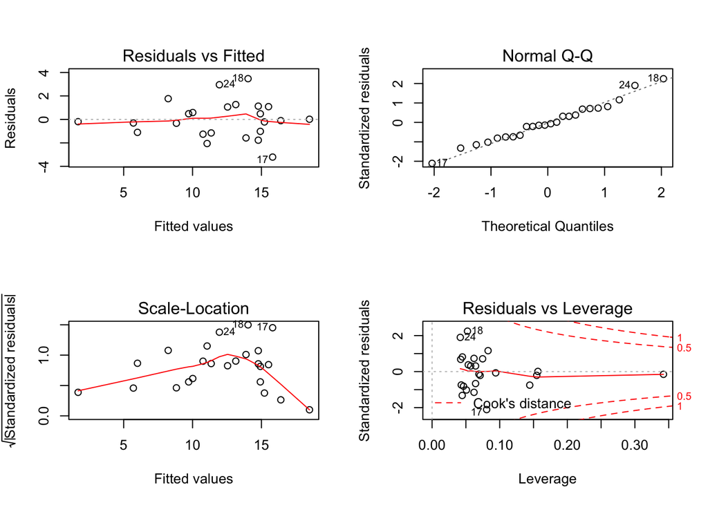

```r
par(mfrow = c(2, 2))
plot(modelo_n_sin_out)
```

Ahora también vemos que se comporta mejor, salvo por algo extraño que ocurre con el gráfico de disperción-ubicación. En general se ajusta bien.

### Regresión para el Peso

Nuevamente repetimos el ejercicio con todos los datos de `ciga`.

```r
modelo_p = lm(CO ~ Pes, ciga)

summary(modelo_p)
```

```
##
## Call:
## lm(formula = CO ~ Pes, data = ciga)
##
## Residuals:
##    Min     1Q Median     3Q    Max
## -6.524 -2.533  0.622  2.842  7.268
##
## Coefficients:
##             Estimate Std. Error t value Pr(>|t|)
## (Intercept)  -11.795      9.722  -1.213   0.2373
## Pes           25.068      9.980   2.512   0.0195 *
## ---
## Signif. codes:  0 '***' 0.001 '**' 0.01 '*' 0.05 '.' 0.1 ' ' 1
##
## Residual standard error: 4.289 on 23 degrees of freedom
## Multiple R-squared:  0.2153, Adjusted R-squared:  0.1811
## F-statistic: 6.309 on 1 and 23 DF,  p-value: 0.01948
```

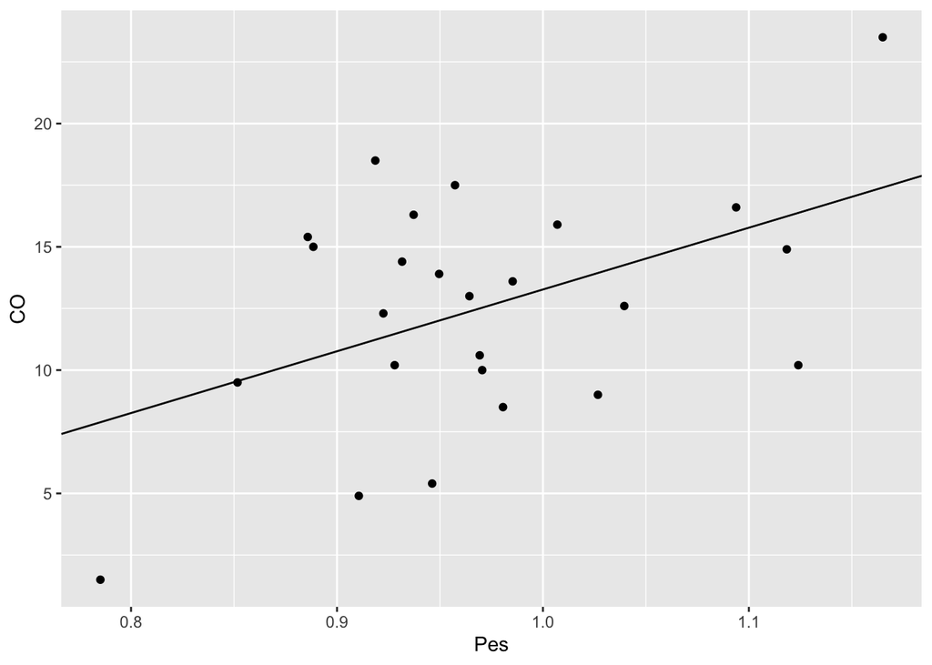

```r
ggplot(ciga, aes(Pes, CO)) +
  geom_point() +
  geom_abline(intercept = modelo_p$coefficients[[1]], slope = modelo_p$coefficients[[2]])
```

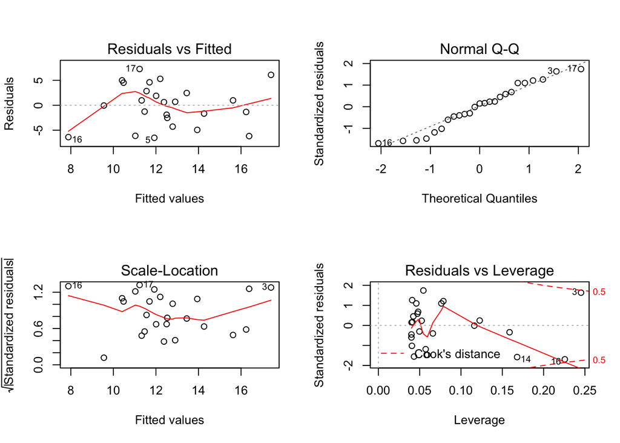

```r
par(mfrow = c(2, 2))
plot(modelo_p)
```

#### Peso sin atípico

Solo por curiosidad vamos a ver cómo se comporta el modelo sin nuestro atípico favorito.

```r
modelo_p_sin_out = lm(CO ~ Pes, ciga_2)

summary(modelo_p_sin_out)
```

```
##
## Call:
## lm(formula = CO ~ Pes, data = ciga_2)
##
## Residuals:
##     Min      1Q  Median      3Q     Max
## -7.6387 -2.6256  0.5641  2.8983  7.1507
##
## Coefficients:
##             Estimate Std. Error t value Pr(>|t|)
## (Intercept)   -3.862     10.445   -0.37    0.715
## Pes           16.559     10.820    1.53    0.140
##
## Residual standard error: 4.123 on 22 degrees of freedom
## Multiple R-squared:  0.09622,    Adjusted R-squared:  0.05514
## F-statistic: 2.342 on 1 and 22 DF,  p-value: 0.1402
```

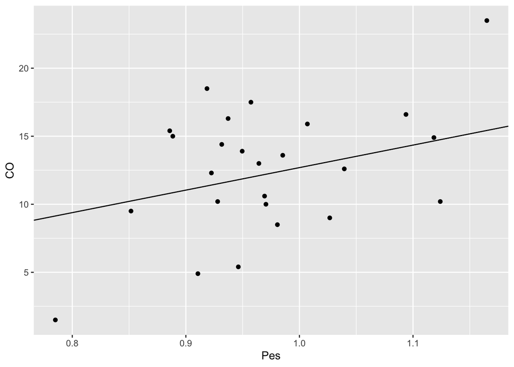

```r
ggplot(ciga, aes(Pes, CO)) +
  geom_point() +
  geom_abline(intercept = modelo_p_sin_out$coefficients[[1]], slope = modelo_p_sin_out$coefficients[[2]])
```

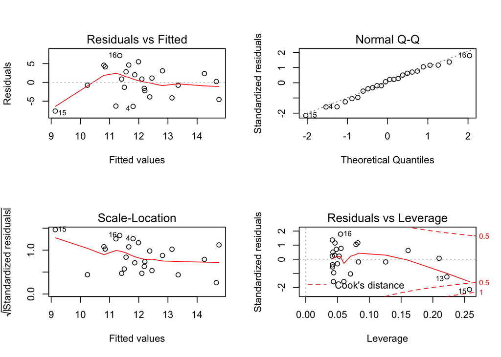

```r
par(mfrow = c(2, 2))
plot(modelo_p_sin_out)
```

Aquí vemos que el modelo empeoró porque el peso se volvió irrelevante para el modelo y el coeficiente de determinación sin la marca BullDurham es de $R^2_{sin_atípico} = 0.0962213$ en comparación con todos los datos $R^2_{todos} = 0.2152581$.

Moraleja: si los datos te dicen que no está roto, no lo intentes reparar.

Lauren, McIntyre. 1994. “Using Cigarette Data for an Introduction to Multiple Regression.” *Journal of Statistics Education* 2 (1).

Mendenhall, William, and Terry Sincich. 1992. *Statistics for Engineering and the Sciences*. 3rd ed. Dellen Publishing Co.